## Validation update - October 22, 2026

The revised R Markdown executed and rendered on 30 provincial totals. Chi-square statistic=7.5941; asymptotic p=0.4741; fixed-null multinomial simulation p=0.4643 with 100,000 replicates and seed 42. Sparse expected counts limit the asymptotic test. This does not prove either fraud or absence of fraud.

# Benford First-Digit Analysis of Provincial Vote Totals

Cameron Batts

## Problem

Compare the first digits of 30 reported provincial vote totals with an explicit Benford reference distribution.

## Verified findings

Independent Python calculation reproduced first-digit counts [5, 4, 5, 3, 2, 4, 3, 1, 3], Pearson χ²=7.5941 (8 degrees of freedom), and the approximate p-value 0.4741. Seven of nine expected digit counts are below five; the smallest is about 1.37.

## Limitations

The asymptotic p-value needs caution because of small expected counts. Non-rejection does not prove conformity, and neither conformity nor deviation establishes election integrity. Population and turnout constrain provincial totals, and the appropriateness of the Benford reference model requires justification. The original repository did not document the upstream election-data source.

## Data

Data/Election2009Iran.csv contains 30 provincial rows. Only Total votes is used for the reported test; candidate names and regional labels remain factual source data.

## Verification

The revised R workflow was executed and rendered on October 22, 2026; see the validation record for current results and package versions.

```r
votes <- read.csv("Data/Election2009Iran.csv", check.names = FALSE)
raw <- votes[["Total votes"]]
totals <- as.numeric(gsub(",", "", as.character(raw), fixed = TRUE))
stopifnot(length(totals) == 30, all(is.finite(totals)), all(totals > 0),
          all(totals == floor(totals)))
first <- as.integer(substr(format(totals, scientific = FALSE, trim = TRUE), 1, 1))
counts <- table(factor(first, levels = 1:9))
expected_probability <- log10(1 + 1/(1:9))
comparison <- data.frame(digit = 1:9, observed = as.integer(counts),
                         expected = length(totals) * expected_probability)
comparison
```

```
##   digit observed expected
## 1     1        5 9.030900
## 2     2        4 5.282738
## 3     3        5 3.748162
## 4     4        3 2.907300
## 5     5        2 2.375437
## 6     6        4 2.008404
## 7     7        3 1.739758
## 8     8        1 1.534576
## 9     9        3 1.372725
```

## Goodness-of-fit checks

```r
# Approximation is retained for comparison, with the expected-count warning visible.
asymptotic <- chisq.test(counts, p = expected_probability)
asymptotic
```

```
##
##  Chi-squared test for given probabilities
##
## data:  counts
## X-squared = 7.5941, df = 8, p-value = 0.4741
```

```r
# Fixed-null multinomial simulation avoids relying on the chi-square asymptotic approximation.
set.seed(42)
simulated <- chisq.test(counts, p = expected_probability, simulate.p.value = TRUE, B = 100000)
simulated
```

```
##
##  Chi-squared test for given probabilities with simulated p-value (based
##  on 1e+05 replicates)
##
## data:  counts
## X-squared = 7.5941, df = NA, p-value = 0.4643
```

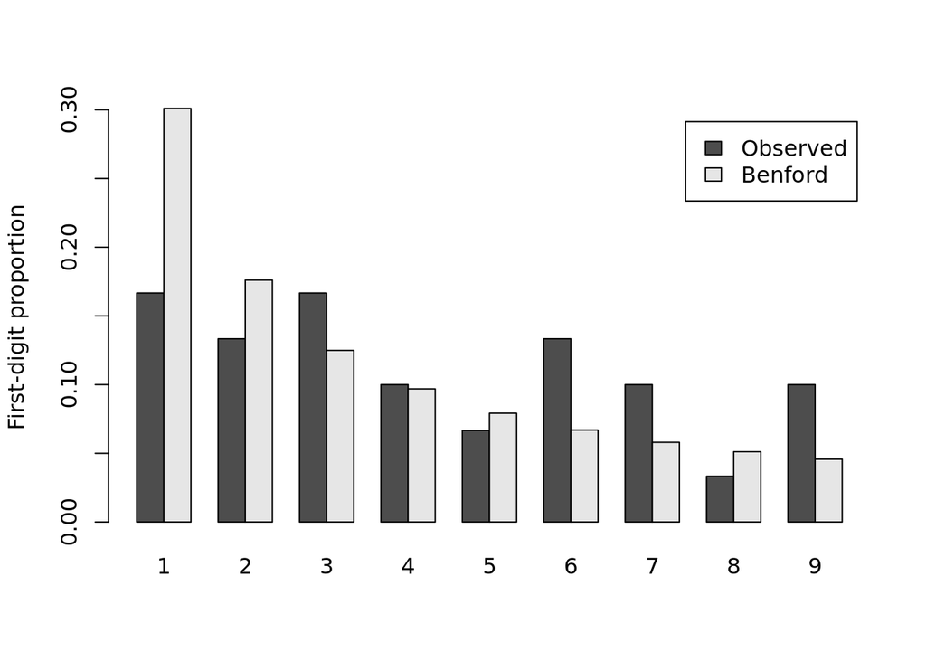

```r
barplot(rbind(comparison$observed / length(totals), expected_probability),
        beside = TRUE, names.arg = 1:9, legend.text = c("Observed", "Benford"),
        ylab = "First-digit proportion")
```

## Method reference

Deckert, Myagkov and Ordeshook (2011), *Benford’s Law and the Detection of Election Fraud*, Political Analysis, doi:10.1093/pan/mpr014. This research discusses limitations of Benford tests for elections.